# CONOCE TU AFP. Conoce tus inversiones.

CONOCE TU AFP. Conoce tus inversiones. Conocer el portafolio de tu AFP te ayudara a entender mejor tus ganancias

## Que es una AFP

Las Administradoras de Fondos de Pensiones (AFP), son instituciones financieras privadas que tienen como único fin la administración de los fondos de pensiones bajo la modalidad de cuentas personales. Otorgan pensiones de jubilación, invalidez, sobrevivencia y proporcionan gastos de sepelio. Las AFP fueron creadas en 1993 y operan dentro del Sistema Privado de Pensiones (SPP), el cual es supervisado y fiscalizado por la Superintendencia de Banca, Seguros y AFP (SBS).

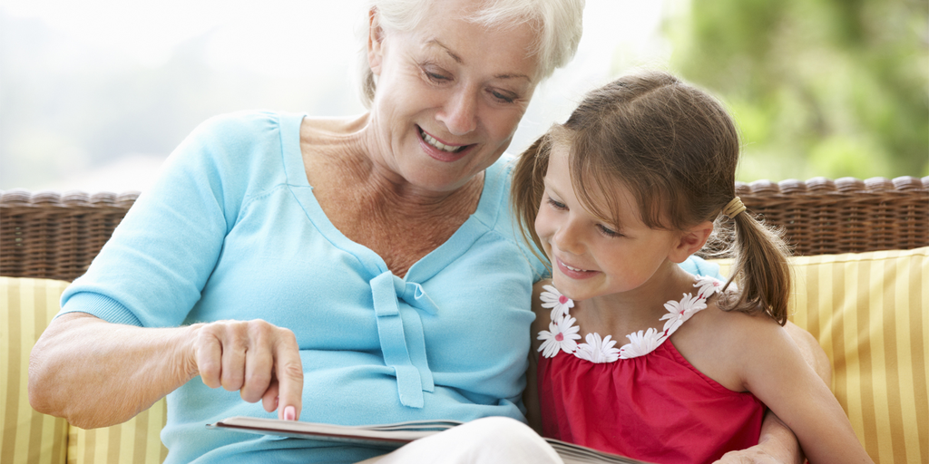

Conoce tu AFP, conoce tus inversiones

[output not shown]

[output not shown]

[output not shown]

[output not shown]

[output not shown]

[output not shown]

[output not shown]

[output not shown]

[output not shown]

[output not shown]

[output not shown]

[output not shown]

[output not shown]

[output not shown]

[output not shown]

[output not shown]

[output not shown]

[output not shown]

[output not shown]

[output not shown]

[output not shown]

[output not shown]

[output not shown]

[output not shown]

[output not shown]

[output not shown]

[output not shown]

## ¿Cuantas AFP’s existen?

En el Perú, hay cuatro: Integra, Hábitat, Prima y Profuturo. Si formas parte del Sistema de Privado de Pensiones, es muy probable que pertenezcas a la AFP que ganó la licitación al momento de tu afiliación. Para estar seguro, solo necesitas consultarlo en la web de la Superintendencia de Banca y Seguros del Perú

### Conoce tu AFP

Apreta [AQUI](https://www2.sbs.gob.pe/afiliados/paginas/Consulta.aspx) para conocer a que AFP estas afiliado

## Analisis de portafolios

### ¿Qué es un portafolio?

También llamado Cartera de Inversión, es una selección de documentos o valores que se cotizan en el mercado bursátil y en los que una persona o empresa deciden colocar o invertir su dinero. Los portafolios de inversión se integran con los diferentes instrumentos que el inversionista haya seleccionado.

### ¿Porqué es importante conocer el portafolio de tu AFP?

Estamos de acuerdo en que invertir es la mejor manera de hacer crecer tu capital, dependiendo siempre del nivel de riesgo que desees asumir. Para que el dinero crezca, existen diferentes instrumentos de inversión que ofrecen menos o más rendimientos con base en el riesgo que representan y la liquidez que ofrecen. Conocer el portafolio de AFP podras conocer un poco mas de certeza como seran sus ganancias y por ende: cuanto ganará tu fondo.

## Análisis de la composicion de portafolios

### 2019

Tenemos:

Cartera por tipo de emisor

Valores en Miles de Soles

| Meses | I. NACIONAL | II. EXTRANJERO | III. OPERACIONES EN TRÁNSITO | TOTAL |
| --- | --- | --- | --- | --- |
| ENERO | 83,475,726.88 | 74,538,178.54 | 175,073.24 | 158,188,978.67 |
| FEBRERO | 82,793,336.73 | 76,082,924.41 | 829,125.45 | 159,705,386.59 |
| MARZO | 81,809,601.08 | 78,510,423.92 | 1,943,020.83 | 162,263,045.83 |
| ABRIL | 83,983,921.38 | 80,022,577.96 | 485,681.32 | 164,492,180.66 |
| MAYO | 88,371,554.32 | 75,251,491.80 | −938,328.56 | 162,684,717.56 |
| JUNIO | 87,011,527.61 | 78,567,082.34 | 175,998.10 | 165,754,608.05 |
| JULIO | 86,836,323.53 | 79,267,510.96 | 1,277,126.86 | 167,380,961.36 |
| AGOSTO | 91,655,959.62 | 76,226,309.16 | 40,515.83 | 167,922,784.61 |
| SEPTIEMBRE | 94,093,226.40 | 75,377,142.78 | −239,328.47 | 169,231,040.70 |
| OCTUBRE | 95,833,821.03 | 75,753,428.64 | −49,147.15 | 171,538,102.52 |

### 2018

Tenemos:

Cartera por tipo de emisor

Valores en Miles de Soles

| Mes | I. NACIONAL | II. EXTRANJERO | III. OPERACIONES EN TRÁNSITO | TOTAL |
| --- | --- | --- | --- | --- |
| ENERO | 89,807,985.95 | 70,288,532.36 | 1,434,089.70 | 161,530,608.00 |
| FEBRERO | 87,873,465.25 | 71,400,319.26 | 598,430.46 | 159,872,214.97 |
| MARZO | 87,817,275.97 | 70,128,498.49 | 816,954.67 | 158,762,729.13 |
| ABRIL | 86,314,450.91 | 71,902,037.06 | 1,188,012.31 | 159,404,500.29 |
| MAYO | 86,371,385.49 | 71,645,749.18 | −397,940.22 | 157,619,194.45 |
| JUNIO | 87,035,813.60 | 69,051,828.57 | −78,656.26 | 156,008,985.91 |
| JULIO | 88,033,076.94 | 71,667,405.38 | −101,730.99 | 159,598,751.33 |
| AGOSTO | 85,367,022.70 | 72,682,833.56 | 496,917.72 | 158,546,773.98 |
| SEPTIEMBRE | 84,972,779.43 | 74,488,353.54 | −611,150.30 | 158,849,982.66 |
| OCTUBRE | 81,947,198.81 | 71,411,633.81 | 146,521.70 | 153,505,354.32 |
| NOVIEMBRE | 86,595,200.71 | 71,206,869.92 | −1,022,317.62 | 156,779,753.01 |
| DICIEMBRE | 84,063,666.89 | 68,367,749.86 | 982,218.77 | 153,413,635.52 |

### 2017

Tenemos:

Cartera por tipo de emisor

Valores en Miles de Soles

| Mes | I. NACIONAL | II. EXTRANJERO | III. OPERACIONES EN TRÁNSITO | TOTAL |
| --- | --- | --- | --- | --- |
| ENERO | 84,702,639.93 | 52,909,484.36 | −1,178,870.54 | 136,433,253.74 |
| FEBRERO | 83,586,407.83 | 54,101,099.86 | −480,085.42 | 137,207,422.28 |
| MARZO | 83,888,984.97 | 55,493,667.88 | −187,089.20 | 139,195,563.64 |
| ABRIL | 84,579,682.91 | 55,859,577.99 | 419,887.95 | 140,859,148.84 |
| MAYO | 85,162,830.08 | 58,984,212.92 | −404,977.27 | 143,742,065.73 |
| JUNIO | 84,166,316.10 | 59,778,103.51 | 472,207.58 | 144,416,627.19 |
| JULIO | 84,247,409.04 | 61,698,563.18 | 366,782.87 | 146,312,755.10 |
| AGOSTO | 83,118,063.19 | 63,513,007.31 | 900,472.99 | 147,531,543.49 |
| SEPTIEMBRE | 85,662,798.51 | 65,985,014.03 | −62,220.28 | 151,585,592.26 |
| OCTUBRE | 87,412,510.42 | 66,979,568.13 | −31,669.58 | 154,360,408.97 |
| NOVIEMBRE | 87,695,158.33 | 67,242,608.27 | −108,106.28 | 154,829,660.32 |
| DICIEMBRE | 88,988,324.16 | 67,706,928.80 | −448,612.44 | 156,246,640.52 |

## Análisis de la composicion de portafolios

### ENERO 2019

## HABITAD

| Localizacion | Fondo0 | Fondo1 | Fondo2 | Fondo3 |
| --- | --- | --- | --- | --- |
| I. NACIONAL | 39943.112735299997 | 314271.72828362463 | 3256994.515826642 | 450320.42735431326 |
| II. EXTRANJERO | 0 | 155346.32912238952 | 2979391.2562748869 | 654749.80507770099 |
| III. OPERACIONES EN TRÁNSITO | -40.507939999999998 | -1574.2993647677995 | -75943.003416478983 | -1288.9832594248001 |

## INTEGRA

| Localizacion | Fondo0 | Fondo1 | Fondo2 | Fondo3 |
| --- | --- | --- | --- | --- |
| I. NACIONAL | 1090426.348553 | 4603183.4918596894 | 24758006.52380776 | 3188760.2066428973 |
| II. EXTRANJERO | 0 | 2180866.1372125652 | 20464881.79513254 | 4778637.4449191447 |
| III. OPERACIONES EN TRÁNSITO | -787.31478000000061 | -52591.149561053142 | -369975.57412283239 | 53555.279206423264 |

## PRIMA

| Localizacion | Fondo0 | Fondo1 | Fondo2 | Fondo3 |
| --- | --- | --- | --- | --- |
| I. NACIONAL | 649657.90566751873 | 2664525.1142776283 | 15364152.595996127 | 2181198.3859032667 |
| II. EXTRANJERO | 0 | 1444817.6802299905 | 14773748.479795659 | 3873920.1162035489 |
| III. OPERACIONES EN TRÁNSITO | -16701.005160000001 | -58517.248841738096 | -471369.88749504322 | -116880.43798444909 |

## PROFUTURO

| Localizacion | Fondo0 | Fondo1 | Fondo2 | Fondo3 |
| --- | --- | --- | --- | --- |
| I. NACIONAL | 621099.85470710183 | 3345268.3448555162 | 18130441.145411495 | 2817477.1822976018 |
| II. EXTRANJERO | 0 | 1837613.7419733349 | 17299166.249381054 | 4095039.5084944125 |
| III. OPERACIONES EN TRÁNSITO | -5972.4110899999996 | 174031.96753150772 | 961706.83179023198 | 157420.98377651689 |

### FEBRERO 2019

## HABITAD

| Localizacion | Fondo0 | Fondo1 | Fondo2 | Fondo3 |
| --- | --- | --- | --- | --- |
| I. NACIONAL | 43707.83725823 | 332896.91162482987 | 3192301.7852613451 | 448048.76028222282 |
| II. EXTRANJERO | 0 | 170705.41640319172 | 3025067.1283270787 | 640883.88954130397 |
| III. OPERACIONES EN TRÁNSITO | -126.83729 | 13221.920472489099 | 98135.08671119099 | 21967.976765386702 |

## INTEGRA

| Localizacion | Fondo0 | Fondo1 | Fondo2 | Fondo3 |
| --- | --- | --- | --- | --- |
| I. NACIONAL | 1120689.5458634999 | 4501007.1606759196 | 23800205.80155139 | 3184634.6191881802 |
| II. EXTRANJERO | 0 | 2312751.4387511974 | 21188151.179640349 | 4750980.6217939062 |
| III. OPERACIONES EN TRÁNSITO | 142.8291300000019 | -6553.7699331789045 | 186330.37213887414 | 110235.432795937 |

## PRIMA

| Localizacion | Fondo0 | Fondo1 | Fondo2 | Fondo3 |
| --- | --- | --- | --- | --- |
| I. NACIONAL | 664857.01861678984 | 2651513.357323207 | 15255328.048043843 | 2197822.665695474 |
| II. EXTRANJERO | 0 | 1443735.3895332159 | 14291010.514799029 | 3710447.1519564423 |
| III. OPERACIONES EN TRÁNSITO | -18324.312440000002 | 9.0248793040955206 | 295567.05293465871 | 70001.194088884775 |

## PROFUTURO

| Localizacion | Fondo0 | Fondo1 | Fondo2 | Fondo3 |
| --- | --- | --- | --- | --- |
| I. NACIONAL | 640971.19793057488 | 3408634.2486003507 | 18499368.047256667 | 2851349.7228898667 |
| II. EXTRANJERO | 0 | 2049796.3865495592 | 18243097.632738493 | 4256297.6619268926 |
| III. OPERACIONES EN TRÁNSITO | -6961.6095000000005 | -28587.874360801397 | 110713.10168213991 | -16644.139948420008 |

## Número de Afiliados Activos por AFP, Tipo de Fondo, Sexo y Rango de Edad

### ENERO 2019

| AFP | Sexo | <21 | 21-25 | 26-30 | 31-35 | 36-40 | 41-45 | 46-50 | 51-55 | 56-60 | 61-65 | 65> | Total |
| --- | --- | --- | --- | --- | --- | --- | --- | --- | --- | --- | --- | --- | --- |
| Habitad | Hombres | 0 | 5 | 2 | 4 | 2 | 2 | 5 | 4 | 0 | 404 | 1048 | 1476 |
| Habitad | Mujeres | 0 | 1 | 2 | 2 | 3 | 2 | 0 | 2 | 5 | 232 | 563 | 812 |
| Integra | Hombres | 0 | 1 | 7 | 23 | 79 | 121 | 158 | 270 | 530 | 5326 | 7242 | 13757 |
| Integra | Mujeres | 0 | 1 | 4 | 12 | 34 | 60 | 118 | 167 | 175 | 1998 | 2611 | 5180 |
| Prima | Hombres | 0 | 5 | 3 | 11 | 18 | 29 | 38 | 57 | 72 | 3532 | 6114 | 9879 |
| Prima | Mujeres | 0 | 1 | 6 | 5 | 12 | 16 | 21 | 22 | 25 | 1140 | 2119 | 3367 |
| Profuturo | Hombres | 0 | 1 | 13 | 40 | 38 | 60 | 88 | 89 | 82 | 5276 | 8121 | 13808 |
| Profuturo | Mujeres | 0 | 0 | 2 | 10 | 21 | 23 | 37 | 21 | 18 | 1596 | 2173 | 3901 |
| Total SPP | Hombres | 0 | 12 | 25 | 78 | 137 | 212 | 289 | 420 | 684 | 14538 | 22525 | 38920 |
| Total SPP | Mujeres | 0 | 3 | 14 | 29 | 70 | 101 | 176 | 212 | 223 | 4966 | 7466 | 13260 |
| Distri. por Rango de Edad (%) | NA | 0 | 0.028746646224607129 | 0.074741280183978534 | 0.20505940973553086 | 0.39670371789957837 | 0.59984668455346879 | 0.89114603296282102 | 1.2111920275967805 | 1.738213875047911 | 37.378305864315827 | 57.476044461479496 | 100 |

| AFP | Sexo | <21 | 21-25 | 26-30 | 31-35 | 36-40 | 41-45 | 46-50 | 51-55 | 56-60 | 61-65 | 65> | Total |
| --- | --- | --- | --- | --- | --- | --- | --- | --- | --- | --- | --- | --- | --- |
| Habitad | Hombres | 0 | 46 | 219 | 250 | 251 | 224 | 153 | 123 | 831 | 2771 | 1151 | 6019 |
| Habitad | Mujeres | 2 | 57 | 169 | 163 | 131 | 88 | 57 | 41 | 571 | 1620 | 617 | 3516 |
| Integra | Hombres | 0 | 7 | 69 | 258 | 624 | 836 | 819 | 811 | 10932 | 36039 | 19799 | 70194 |
| Integra | Mujeres | 0 | 3 | 48 | 212 | 429 | 517 | 488 | 412 | 5303 | 16232 | 7068 | 30712 |
| Prima | Hombres | 0 | 16 | 102 | 293 | 625 | 744 | 662 | 660 | 7525 | 25370 | 13094 | 49091 |
| Prima | Mujeres | 0 | 14 | 99 | 266 | 439 | 433 | 315 | 268 | 3159 | 10129 | 4096 | 19218 |
| Profuturo | Hombres | 0 | 3 | 55 | 237 | 515 | 648 | 674 | 587 | 10857 | 35861 | 27294 | 76731 |
| Profuturo | Mujeres | 0 | 2 | 26 | 166 | 297 | 342 | 289 | 226 | 4134 | 12611 | 8926 | 27019 |
| Total SPP | Hombres | 0 | 72 | 445 | 1038 | 2015 | 2452 | 2308 | 2181 | 30145 | 100041 | 61338 | 202035 |
| Total SPP | Mujeres | 2 | 76 | 342 | 807 | 1296 | 1380 | 1149 | 947 | 13167 | 40592 | 20707 | 80465 |
| Distri. por Rango de Edad (%) | NA | 0.00070796460176991152 | 0.052389380530973452 | 0.27858407079646019 | 0.65309734513274331 | 1.1720353982300884 | 1.3564601769911504 | 1.223716814159292 | 1.1072566371681416 | 15.331681415929204 | 49.78159292035398 | 29.042477876106194 | 100 |

| AFP | Sexo | <21 | 21-25 | 26-30 | 31-35 | 36-40 | 41-45 | 46-50 | 51-55 | 56-60 | 61-65 | 65> | Total |
| --- | --- | --- | --- | --- | --- | --- | --- | --- | --- | --- | --- | --- | --- |
| Habitad | Hombres | 19350 | 224270 | 164246 | 75683 | 37290 | 22730 | 13144 | 9526 | 5721 | 777 | 568 | 573305 |
| Habitad | Mujeres | 13961 | 180355 | 146090 | 62075 | 32664 | 21305 | 13130 | 8212 | 4208 | 394 | 282 | 482676 |
| Integra | Hombres | 107 | 16804 | 115570 | 167872 | 194368 | 194799 | 159817 | 123165 | 79385 | 18555 | 13339 | 1083781 |
| Integra | Mujeres | 98 | 12671 | 82150 | 114369 | 131002 | 128854 | 104132 | 73404 | 42194 | 8740 | 4809 | 702423 |
| Prima | Hombres | 82813 | 181068 | 183906 | 171686 | 153506 | 141179 | 112014 | 84195 | 55439 | 12343 | 9177 | 1187326 |
| Prima | Mujeres | 60774 | 146624 | 149791 | 137417 | 112841 | 90632 | 66176 | 44464 | 24953 | 4798 | 2839 | 841309 |
| Profuturo | Hombres | 5 | 11737 | 94653 | 157051 | 181980 | 182700 | 164982 | 131343 | 84674 | 20963 | 14233 | 1044321 |
| Profuturo | Mujeres | 3 | 6877 | 53297 | 86408 | 103581 | 101724 | 86603 | 62178 | 35979 | 8556 | 4560 | 549766 |
| Total SPP | Hombres | 102275 | 433879 | 558375 | 572292 | 567144 | 541408 | 449957 | 348229 | 225219 | 52638 | 37317 | 3888733 |
| Total SPP | Mujeres | 74836 | 346527 | 431328 | 400269 | 380088 | 342515 | 270041 | 188258 | 107334 | 22488 | 12490 | 2576174 |
| Distri. por Rango de Edad (%) | NA | 2.7395753720819185 | 12.071418815460145 | 15.308851310622101 | 15.043696684267848 | 14.651904505354834 | 13.672632877781536 | 11.137020223183411 | 8.2984488407953894 | 5.1439719086446258 | 1.1620584797275506 | 0.77042098208063936 | 100 |

[output not shown]

### FEBRERO 2019

| AFP | Sexo | <21 | 21-25 | 26-30 | 31-35 | 36-40 | 41-45 | 46-50 | 51-55 | 56-60 | 61-65 | 65> | Total |
| --- | --- | --- | --- | --- | --- | --- | --- | --- | --- | --- | --- | --- | --- |
| Habitad | Hombres | 0 | 5 | 2 | 3 | 1 | 4 | 5 | 4 | 1 | 412 | 1067 | 1504 |
| Habitad | Mujeres | 0 | 2 | 4 | 2 | 3 | 2 | 0 | 2 | 4 | 237 | 577 | 833 |
| Integra | Hombres | 0 | 1 | 7 | 28 | 78 | 121 | 168 | 279 | 550 | 5482 | 7597 | 14311 |
| Integra | Mujeres | 0 | 1 | 4 | 12 | 33 | 63 | 133 | 163 | 179 | 2069 | 2710 | 5367 |
| Prima | Hombres | 0 | 5 | 2 | 13 | 20 | 26 | 40 | 62 | 72 | 3585 | 6380 | 10205 |
| Prima | Mujeres | 0 | 1 | 4 | 7 | 10 | 21 | 26 | 27 | 27 | 1193 | 2245 | 3561 |
| Profuturo | Hombres | 0 | 0 | 12 | 40 | 36 | 56 | 83 | 86 | 82 | 5346 | 8444 | 14185 |
| Profuturo | Mujeres | 0 | 0 | 2 | 11 | 20 | 23 | 39 | 19 | 18 | 1622 | 2283 | 4037 |
| Total SPP | Hombres | 0 | 11 | 23 | 84 | 135 | 207 | 296 | 431 | 705 | 14825 | 23488 | 40205 |
| Total SPP | Mujeres | 0 | 4 | 14 | 32 | 66 | 109 | 198 | 211 | 228 | 5121 | 7815 | 13798 |
| Distri. por Rango de Edad (%) | NA | 0 | 0.027776234653630355 | 0.068514712145621534 | 0.21480288132140807 | 0.37220154435864672 | 0.58515267670314608 | 0.91476399459289304 | 1.1888228431753791 | 1.7276817954558079 | 36.934985093420735 | 57.965298224172734 | 100 |

| AFP | Sexo | <21 | 21-25 | 26-30 | 31-35 | 36-40 | 41-45 | 46-50 | 51-55 | 56-60 | 61-65 | 65> | Total |
| --- | --- | --- | --- | --- | --- | --- | --- | --- | --- | --- | --- | --- | --- |
| Habitad | Hombres | 0 | 50 | 234 | 266 | 272 | 231 | 176 | 138 | 873 | 2754 | 1141 | 6135 |
| Habitad | Mujeres | 2 | 60 | 174 | 170 | 140 | 100 | 64 | 44 | 610 | 1615 | 611 | 3590 |
| Integra | Hombres | 0 | 7 | 70 | 261 | 628 | 847 | 830 | 830 | 11233 | 36120 | 19735 | 70561 |
| Integra | Mujeres | 0 | 4 | 51 | 209 | 437 | 518 | 507 | 417 | 5400 | 16328 | 7042 | 30913 |
| Prima | Hombres | 0 | 15 | 106 | 300 | 641 | 761 | 673 | 677 | 7698 | 25556 | 13069 | 49496 |
| Prima | Mujeres | 1 | 20 | 103 | 266 | 444 | 454 | 326 | 273 | 3234 | 10220 | 4100 | 19441 |
| Profuturo | Hombres | 0 | 3 | 53 | 235 | 512 | 650 | 681 | 609 | 11135 | 36006 | 27126 | 77010 |
| Profuturo | Mujeres | 0 | 2 | 28 | 162 | 297 | 343 | 295 | 227 | 4198 | 12687 | 8889 | 27128 |
| Total SPP | Hombres | 0 | 75 | 463 | 1062 | 2053 | 2489 | 2360 | 2254 | 30939 | 100436 | 61071 | 203202 |
| Total SPP | Mujeres | 3 | 86 | 356 | 807 | 1318 | 1415 | 1192 | 961 | 13442 | 40850 | 20642 | 81072 |
| Distri. por Rango de Edad (%) | NA | 0.0010553198674518247 | 0.056635499553247926 | 0.28810232381434814 | 0.65746427742248681 | 1.1858277577267002 | 1.3733229208439746 | 1.2494987230629604 | 1.1309511246192054 | 15.612050345793143 | 49.700640930932835 | 28.744450776363649 | 100 |

| AFP | Sexo | <21 | 21-25 | 26-30 | 31-35 | 36-40 | 41-45 | 46-50 | 51-55 | 56-60 | 61-65 | 65> | Total |
| --- | --- | --- | --- | --- | --- | --- | --- | --- | --- | --- | --- | --- | --- |
| Habitad | Hombres | 17409 | 221777 | 165240 | 76754 | 37594 | 22970 | 13243 | 9556 | 5752 | 806 | 591 | 571692 |
| Habitad | Mujeres | 12473 | 177834 | 147071 | 62830 | 32883 | 21408 | 13170 | 8247 | 4242 | 403 | 293 | 480854 |
| Integra | Hombres | 105 | 15944 | 114320 | 167327 | 194340 | 195268 | 160271 | 123815 | 79517 | 18726 | 13684 | 1083317 |
| Integra | Mujeres | 83 | 12133 | 81219 | 114309 | 130928 | 129058 | 104613 | 73935 | 42429 | 8838 | 5001 | 702546 |
| Prima | Hombres | 86607 | 188083 | 187582 | 173897 | 154768 | 142241 | 112828 | 84959 | 55733 | 12519 | 9422 | 1208639 |
| Prima | Mujeres | 63579 | 152468 | 152925 | 139224 | 114328 | 91500 | 66874 | 44976 | 25219 | 4898 | 2881 | 858872 |
| Profuturo | Hombres | 5 | 10940 | 93027 | 156435 | 181793 | 182774 | 165220 | 131943 | 84878 | 21083 | 14742 | 1042840 |
| Profuturo | Mujeres | 3 | 6397 | 52381 | 86115 | 103441 | 101665 | 86904 | 62508 | 36234 | 8647 | 4703 | 548998 |
| Total SPP | Hombres | 104126 | 436744 | 560169 | 574413 | 568495 | 543253 | 451562 | 350273 | 225880 | 53134 | 38439 | 3906488 |
| Total SPP | Mujeres | 76138 | 348832 | 433596 | 402478 | 381580 | 343631 | 271561 | 189666 | 108124 | 22786 | 12878 | 2591270 |
| Distri. por Rango de Edad (%) | NA | 2.7742492102660639 | 12.089954719766418 | 15.293967550038028 | 15.03427797711149 | 14.621581782516369 | 13.649077112444015 | 11.128807813402716 | 8.3096200258612285 | 5.1402960836645502 | 1.168403009161006 | 0.78976471576811569 | 100 |

[output not shown]

## Número de Afiliados Activos por AFP, Departamento y Sexo

### Enero 2019

| AFP | Sexo | Amazonas | Ancash | Apurimac | Arequipa | Ayacucho | Cajamarca | Callao | Cusco | Huancavelica | Huanuco | Ica | Junin | La Libertad | Lambayeque | Lima | Loreto | Madre De Dios | Moquegua | Pasco | Piura | Puno | San Martin | Tacna | Tumbes | Ucayali | Extranjero | Sin Informacion | Total |
| --- | --- | --- | --- | --- | --- | --- | --- | --- | --- | --- | --- | --- | --- | --- | --- | --- | --- | --- | --- | --- | --- | --- | --- | --- | --- | --- | --- | --- | --- |
| Habitat | Hombres | 4242 | 12059 | 8715 | 24740 | 5912 | 17365 | 24622 | 26366 | 4258 | 8047 | 16616 | 12408 | 33400 | 23200 | 258825 | 19701 | 2268 | 2338 | 2404 | 32082 | 13307 | 15419 | 4421 | 3233 | 9460 | 1 | 4 | 585413 |
| Habitad | Mujeres | 2134 | 8755 | 5336 | 21357 | 5028 | 10265 | 22826 | 20003 | 3338 | 5463 | 15015 | 10618 | 29260 | 18918 | 237597 | 7844 | 1703 | 2416 | 1587 | 27705 | 9070 | 8129 | 4455 | 3005 | 5643 | 1 | 6 | 487477 |
| Integra | Hombres | 6081 | 40211 | 7201 | 56770 | 23219 | 37187 | 55812 | 46532 | 9276 | 15517 | 53634 | 37292 | 80275 | 35002 | 510838 | 33039 | 2533 | 16355 | 5376 | 61627 | 31599 | 20756 | 23338 | 7370 | 20138 | 836 | 58 | 1237872 |
| Integra | Mujeres | 2633 | 21361 | 3808 | 34080 | 10525 | 14352 | 38423 | 20780 | 2773 | 7109 | 45272 | 18357 | 44931 | 21922 | 376152 | 13996 | 1308 | 9533 | 1761 | 35825 | 12623 | 9146 | 13097 | 3264 | 9512 | 650 | 17 | 773210 |
| Prima | Hombres | 5613 | 30311 | 7176 | 52993 | 9403 | 35165 | 58267 | 47768 | 6058 | 13507 | 34086 | 35476 | 92380 | 56088 | 575548 | 33671 | 4104 | 9292 | 7723 | 79503 | 19867 | 38268 | 9982 | 6916 | 21508 | 88 | 3464 | 1294225 |
| Prima | Mujeres | 2310 | 17782 | 3643 | 34981 | 4640 | 19126 | 39899 | 25421 | 3164 | 8654 | 30586 | 23353 | 64124 | 42925 | 438745 | 15588 | 2299 | 5610 | 4964 | 54927 | 9488 | 13272 | 6959 | 4838 | 9410 | 33 | 3153 | 889894 |
| Profuturo | Hombres | 7572 | 35588 | 6342 | 52451 | 16284 | 37764 | 53826 | 51435 | 11777 | 23502 | 41423 | 40983 | 65200 | 32118 | 482233 | 35738 | 4990 | 9981 | 9129 | 66561 | 36367 | 25559 | 19663 | 8492 | 15153 | 167 | 0 | 1190298 |
| Profuturo | Mujeres | 1984 | 13830 | 2020 | 28096 | 4622 | 11153 | 30755 | 15077 | 2642 | 9350 | 30806 | 17607 | 31933 | 14495 | 291154 | 15322 | 2118 | 4988 | 2259 | 34548 | 10203 | 8849 | 9506 | 4010 | 5396 | 108 | 0 | 602831 |
| Total | Hombres | 23508 | 118169 | 29434 | 186954 | 54818 | 127481 | 192527 | 172101 | 31369 | 60573 | 145759 | 126159 | 271255 | 146408 | 1827444 | 122149 | 13895 | 37966 | 24632 | 239773 | 101140 | 100002 | 57404 | 26011 | 66259 | 1092 | 3526 | 4307808 |
| Total | Mujeres | 9061 | 61728 | 14807 | 118514 | 24815 | 54896 | 131903 | 81281 | 11917 | 30576 | 121679 | 69935 | 170248 | 98260 | 1343648 | 52750 | 7428 | 22547 | 10571 | 153005 | 41384 | 39396 | 34017 | 15117 | 29961 | 792 | 3176 | 2753412 |
| Porcentaje | % | 0.46123757650944169 | 2.5476758973661773 | 0.6265347914383067 | 4.3259946581468922 | 1.1277512951019797 | 2.5827973069809467 | 4.5945318231127201 | 3.5883600850844473 | 0.6130102163648774 | 1.2908392600712058 | 3.7874191711913809 | 2.7770555229832805 | 6.2525031085279874 | 3.464953648236424 | 44.90855687827316 | 2.4768949275054455 | 0.30197331339343625 | 0.85697655645908222 | 0.49853991236641826 | 5.5624665426087843 | 2.0184047515868362 | 1.9741347812417684 | 1.294691285641858 | 0.58244892525654202 | 1.3626540456181793 | 0.026680941820252026 | 0.094912777112170416 | 100 |

### Febrero 2019

| AFP | Sexo | Amazonas | Ancash | Apurimac | Arequipa | Ayacucho | Cajamarca | Callao | Cusco | Huancavelica | Huanuco | Ica | Junin | La Libertad | Lambayeque | Lima | Loreto | Madre De Dios | Moquegua | Pasco | Piura | Puno | San Martin | Tacna | Tumbes | Ucayali | Extranjero | Sin Informacion | Total |
| --- | --- | --- | --- | --- | --- | --- | --- | --- | --- | --- | --- | --- | --- | --- | --- | --- | --- | --- | --- | --- | --- | --- | --- | --- | --- | --- | --- | --- | --- |
| Habitat | Hombres | 4222 | 12004 | 8704 | 24729 | 5872 | 17296 | 24562 | 26329 | 4211 | 8027 | 16469 | 12395 | 33200 | 23052 | 258265 | 19606 | 2268 | 2337 | 2388 | 31867 | 13296 | 15368 | 4422 | 3225 | 9422 | 1 | 4 | 583541 |
| Habitad | Mujeres | 2126 | 8699 | 5325 | 21312 | 4995 | 10208 | 22736 | 19937 | 3296 | 5454 | 14811 | 10585 | 29035 | 18755 | 236728 | 7811 | 1703 | 2415 | 1579 | 27504 | 9053 | 8112 | 4450 | 3002 | 5632 | 1 | 6 | 485270 |
| Integra | Hombres | 6075 | 40221 | 7199 | 56769 | 23218 | 37177 | 55827 | 46527 | 9276 | 15517 | 53616 | 37306 | 80274 | 34999 | 510943 | 33025 | 2532 | 16361 | 5376 | 61660 | 31600 | 20745 | 23344 | 7371 | 20141 | 836 | 58 | 1237993 |
| Integra | Mujeres | 2626 | 21371 | 3804 | 34089 | 10520 | 14340 | 38460 | 20785 | 2776 | 7108 | 45264 | 18365 | 44934 | 21948 | 376345 | 13993 | 1308 | 9535 | 1761 | 35858 | 12627 | 9127 | 13100 | 3261 | 9512 | 650 | 17 | 773484 |
| Prima | Hombres | 5762 | 30704 | 7290 | 53692 | 9670 | 35801 | 59159 | 48430 | 6235 | 13765 | 34890 | 35807 | 94326 | 57115 | 585677 | 34149 | 4162 | 9385 | 7792 | 80706 | 20164 | 38808 | 10124 | 6991 | 21799 | 88 | 3703 | 1316194 |
| Prima | Mujeres | 2371 | 18069 | 3738 | 35543 | 4853 | 19482 | 40636 | 25965 | 3322 | 8807 | 31366 | 23693 | 65821 | 43851 | 447440 | 15808 | 2341 | 5693 | 5022 | 55868 | 9690 | 13521 | 7087 | 4914 | 9624 | 33 | 3360 | 907918 |
| Profuturo | Hombres | 7579 | 35573 | 6338 | 52410 | 16276 | 37764 | 53800 | 51406 | 11773 | 23494 | 41397 | 40951 | 65158 | 32103 | 481973 | 35750 | 4985 | 9976 | 9119 | 66533 | 36348 | 25574 | 19654 | 8485 | 15146 | 167 | 0 | 1189732 |
| Profuturo | Mujeres | 1991 | 13827 | 2020 | 28081 | 4617 | 11167 | 30749 | 15073 | 2642 | 9346 | 30797 | 17605 | 31921 | 14492 | 291142 | 15336 | 2117 | 4985 | 2258 | 34535 | 10198 | 8870 | 9501 | 4008 | 5396 | 108 | 0 | 602782 |
| Total | Hombres | 23638 | 118502 | 29531 | 187600 | 55036 | 128038 | 193348 | 172692 | 31495 | 60803 | 146372 | 126459 | 272958 | 147269 | 1836858 | 122530 | 13947 | 38059 | 24675 | 240766 | 101408 | 100495 | 57544 | 26072 | 66508 | 1092 | 3765 | 4327460 |
| Total | Mujeres | 9114 | 61966 | 14887 | 119025 | 24985 | 55197 | 132581 | 81760 | 12036 | 30715 | 122238 | 70248 | 171711 | 99046 | 1351655 | 52948 | 7469 | 22628 | 10620 | 153765 | 41568 | 39630 | 34138 | 15185 | 30164 | 792 | 3383 | 2769454 |
| Porcentaje | % | 0.46149636306710212 | 2.5429080865288771 | 0.62587767020989693 | 4.3205398853642585 | 1.1275464236990895 | 2.5818968639045083 | 4.5925454359458211 | 3.5853893678294537 | 0.61337928006454634 | 1.28954641411746 | 3.7848845286838761 | 2.7717258515461789 | 6.265667020905143 | 3.4707338992694572 | 44.928161733395669 | 2.4725958353165898 | 0.30176496432111194 | 0.8551181541723627 | 0.49732883898550834 | 5.5591909384839662 | 2.0146221301258547 | 1.9744497397037641 | 1.2918572776843569 | 0.58133718402111112 | 1.3621695288966444 | 0.026546749756302526 | 0.10071983400108836 | 100 |

### Marzo 2019

| AFP | Sexo | Amazonas | Ancash | Apurimac | Arequipa | Ayacucho | Cajamarca | Callao | Cusco | Huancavelica | Huanuco | Ica | Junin | La Libertad | Lambayeque | Lima | Loreto | Madre De Dios | Moquegua | Pasco | Piura | Puno | San Martin | Tacna | Tumbes | Ucayali | Extranjero | Sin Informacion | Total |
| --- | --- | --- | --- | --- | --- | --- | --- | --- | --- | --- | --- | --- | --- | --- | --- | --- | --- | --- | --- | --- | --- | --- | --- | --- | --- | --- | --- | --- | --- |
| Habitat | Hombres | 4198 | 11948 | 8702 | 24728 | 5852 | 17234 | 24490 | 26251 | 4170 | 8012 | 16368 | 12399 | 33060 | 22918 | 257536 | 19531 | 2262 | 2334 | 2382 | 31680 | 13292 | 15326 | 4424 | 3223 | 9389 | 2 | 4 | 581715 |
| Habitad | Mujeres | 2119 | 8632 | 5317 | 21269 | 4978 | 10173 | 22632 | 19895 | 3269 | 5441 | 14699 | 10556 | 28867 | 18605 | 235857 | 7774 | 1701 | 2414 | 1573 | 27278 | 9029 | 8096 | 4442 | 2999 | 5618 | 1 | 6 | 483240 |
| Integra | Hombres | 6071 | 40246 | 7195 | 56755 | 23224 | 37177 | 55851 | 46531 | 9277 | 15516 | 53615 | 37292 | 80273 | 35002 | 511029 | 33024 | 2535 | 16355 | 5368 | 61673 | 31598 | 20735 | 23344 | 7369 | 20144 | 836 | 58 | 1238093 |
| Integra | Mujeres | 2620 | 21406 | 3806 | 34088 | 10521 | 14332 | 38504 | 20789 | 2776 | 7107 | 45260 | 18376 | 44942 | 21982 | 376555 | 13985 | 1309 | 9534 | 1761 | 35866 | 12636 | 9115 | 13103 | 3259 | 9512 | 650 | 17 | 773811 |
| Prima | Hombres | 5893 | 31064 | 7414 | 54470 | 9975 | 36302 | 60031 | 49315 | 6386 | 14004 | 35559 | 36190 | 95368 | 57977 | 595781 | 34655 | 4217 | 9470 | 7868 | 81819 | 20553 | 39250 | 10292 | 7079 | 22107 | 88 | 3853 | 1336980 |
| Prima | Mujeres | 2439 | 18425 | 3813 | 36194 | 5053 | 19794 | 41378 | 26726 | 3465 | 8985 | 32031 | 24062 | 66765 | 44649 | 456622 | 16082 | 2392 | 5768 | 5103 | 56791 | 10005 | 13744 | 7268 | 5008 | 9868 | 33 | 3490 | 925953 |
| Profuturo | Hombres | 7589 | 35564 | 6338 | 52367 | 16264 | 37757 | 53771 | 51397 | 11768 | 23493 | 41389 | 40919 | 65130 | 32092 | 481798 | 35768 | 4985 | 9975 | 9116 | 66500 | 36328 | 25582 | 19647 | 8485 | 15142 | 167 | 0 | 1189331 |
| Profuturo | Mujeres | 1999 | 13822 | 2021 | 28075 | 4612 | 11173 | 30750 | 15072 | 2642 | 9344 | 30795 | 17601 | 31903 | 14494 | 291132 | 15373 | 2117 | 4985 | 2255 | 34528 | 10195 | 8888 | 9496 | 4006 | 5394 | 108 | 0 | 602780 |
| Total | Hombres | 23751 | 118822 | 29649 | 188320 | 55315 | 128470 | 194143 | 173494 | 31601 | 61025 | 146931 | 126800 | 273831 | 147989 | 1846144 | 122978 | 13999 | 38134 | 24734 | 241672 | 101771 | 100893 | 57707 | 26156 | 66782 | 1093 | 3915 | 4346119 |
| Total | Mujeres | 9177 | 62285 | 14957 | 119626 | 25164 | 55472 | 133264 | 82482 | 12152 | 30877 | 122785 | 70595 | 172477 | 99730 | 1360166 | 53214 | 7519 | 22701 | 10692 | 154463 | 41865 | 39843 | 34309 | 15272 | 30392 | 792 | 3513 | 2785784 |
| Porcentaje | % | 0.46170005396876546 | 2.5393923613374998 | 0.62544316713225068 | 4.3178657926222499 | 1.1284365477208538 | 2.5791433226166984 | 4.5907382643874994 | 3.58916827668576 | 0.61348282499074935 | 1.2886041775946755 | 3.7818237292346799 | 2.7677746037768602 | 6.2579090040904939 | 3.4733927256161508 | 44.957285594041309 | 2.4704766736171258 | 0.30171470363520086 | 0.85299814088890447 | 0.49672576870436963 | 5.5544081292188077 | 2.0139926188003399 | 1.9733302598198543 | 1.2902026289477015 | 0.58088283029087751 | 1.3625255419205786 | 0.026430533337315439 | 0.10415172500242924 | 100 |

### Enero 2019

| Tipo de Fondo | AFP | Ene-2018 | Feb-2018 | Mar-2018 | Abr-2018 | May-2018 | Jun-2018 | Jul-2018 | Ago-2018 | Set-2018 | Oct-2018 | Nov-2018 | Dic-2018 | Ene-2019 |
| --- | --- | --- | --- | --- | --- | --- | --- | --- | --- | --- | --- | --- | --- | --- |
| Fondo 0 | Habitat | 10.87467 | 10.91636 | 10.95870 | 10.99904 | 11.03577 | 11.06858 | 11.10226 | 11.13627 | 11.17048 | 11.20430 | 11.24185 | 11.27829 | 11.32102 |
| Fondo 0 | Integra | 10.86261 | 10.89651 | 10.92845 | 10.95940 | 10.98998 | 11.02079 | 11.05060 | 11.08236 | 11.11305 | 11.14397 | 11.17674 | 11.20986 | 11.24683 |
| Fondo 0 | Prima | 10.80847 | 10.83850 | 10.87012 | 10.90171 | 10.93300 | 10.96319 | 10.99657 | 11.03065 | 11.06369 | 11.09630 | 11.13015 | 11.16494 | 11.20545 |
| Fondo 0 | Profuturo | 10.86591 | 10.90127 | 10.93492 | 10.96829 | 11.00165 | 11.03520 | 11.06924 | 11.10427 | 11.13792 | 11.17205 | 11.20868 | 11.24397 | 11.28394 |

| Tipo de Fondo | AFP | Ene-2018 | Feb-2018 | Mar-2018 | Abr-2018 | May-2018 | Jun-2018 | Jul-2018 | Ago-2018 | Set-2018 | Oct-2018 | Nov-2018 | Dic-2018 | Ene-2019 |
| --- | --- | --- | --- | --- | --- | --- | --- | --- | --- | --- | --- | --- | --- | --- |
| Fondo 1 | Habitat | 15.06400 | 15.14915 | 15.16620 | 15.07719 | 14.88012 | 14.77450 | 14.92819 | 15.04322 | 15.03563 | 14.96409 | 14.86333 | 14.90869 | 15.14695 |
| Fondo 1 | Integra | 23.86419 | 23.98996 | 23.97719 | 23.88388 | 23.50204 | 23.25147 | 23.51602 | 23.69028 | 23.65992 | 23.53319 | 23.43245 | 23.49589 | 23.79077 |
| Fondo 1 | Prima | 24.53440 | 24.65064 | 24.64874 | 24.58894 | 24.21782 | 23.99227 | 24.30356 | 24.43655 | 24.39355 | 24.23656 | 24.02871 | 24.17981 | 24.59340 |
| Fondo 1 | Profuturo | 22.83994 | 22.96536 | 22.96991 | 22.84518 | 22.56625 | 22.39084 | 22.63642 | 22.73306 | 22.66870 | 22.51663 | 22.39074 | 22.47247 | 22.83346 |

| Tipo de Fondo | AFP | Ene-2018 | Feb-2018 | Mar-2018 | Abr-2018 | May-2018 | Jun-2018 | Jul-2018 | Ago-2018 | Set-2018 | Oct-2018 | Nov-2018 | Dic-2018 | Ene-2019 |
| --- | --- | --- | --- | --- | --- | --- | --- | --- | --- | --- | --- | --- | --- | --- |
| Fondo 2 | Habitat | 15.85498 | 15.8022 | 15.80537 | 15.65801 | 15.63045 | 15.52897 | 15.52737 | 15.58602 | 15.56754 | 15.25019 | 15.10965 | 14.94251 | 15.17500 |
| Fondo 2 | Integra | 180.82914 | 179.5683 | 179.02235 | 178.00223 | 178.18138 | 176.54178 | 176.62066 | 177.64036 | 177.27080 | 173.92457 | 174.38797 | 172.49423 | 174.48653 |
| Fondo 2 | Prima | 33.78949 | 33.6458 | 33.53352 | 33.36022 | 33.24934 | 32.89698 | 33.04457 | 33.23634 | 33.19359 | 32.68356 | 32.66146 | 32.40224 | 32.88338 |
| Fondo 2 | Profuturo | 169.57824 | 168.7931 | 168.56137 | 167.37765 | 167.89621 | 166.64858 | 166.85810 | 167.68380 | 167.33635 | 164.32215 | 164.01791 | 162.72545 | 164.65219 |

| Tipo de Fondo | AFP | Ene-2018 | Feb-2018 | Mar-2018 | Abr-2018 | May-2018 | Jun-2018 | Jul-2018 | Ago-2018 | Set-2018 | Oct-2018 | Nov-2018 | Dic-2018 | Ene-2019 |
| --- | --- | --- | --- | --- | --- | --- | --- | --- | --- | --- | --- | --- | --- | --- |
| Fondo 3 | Habitat | 15.09759 | 14.87511 | 14.85903 | 14.74082 | 14.89963 | 14.78215 | 14.55150 | 14.55555 | 14.48152 | 14.05634 | 13.86734 | 13.61991 | 13.85499 |
| Fondo 3 | Integra | 43.03448 | 42.21906 | 41.99836 | 41.97320 | 42.68359 | 42.18111 | 41.58956 | 41.65067 | 41.26029 | 40.12978 | 40.33184 | 39.69827 | 40.04906 |
| Fondo 3 | Prima | 40.42207 | 39.71722 | 39.46118 | 39.44057 | 39.83998 | 39.30456 | 38.96499 | 39.06460 | 38.77477 | 37.86279 | 37.93249 | 37.32810 | 37.74391 |
| Fondo 3 | Profuturo | 38.96728 | 38.31234 | 38.24571 | 38.17681 | 38.94883 | 38.66178 | 38.20916 | 38.21822 | 37.86257 | 36.88693 | 36.88374 | 36.41985 | 36.72531 |

## Ranking de Rentabilidad Ajustada por Riesgo según Tipo de Fondo (Indicador de Rentabilidad Ajustada por Riesgo Anualizada) y AFP

### Enero 2019

| Ranking | AFP | Enero 19 | Tamaño del Fondo de Pensiones (Millones de soles) |
| --- | --- | --- | --- |
| 1ro (PRIMERO) | Integra | 27.7926 | 1089.6390329999999 |
| 2do (SEGUNDO) | Profuturo | 27.527100000000001 | 632.95690000000002 |
| 3ro (TERCERO) | Prima | 26.465599999999998 | 615.12744299999997 |
| 4To (CUARTO) | Hábitat | 23.076599999999999 | 39.902603999999997 |

### Febrero 2019

| Ranking | AFP | Febrero 19 | Tamaño del Fondo de Pensiones (Millones de soles) |
| --- | --- | --- | --- |
| 1ro (PRIMERO) | Integra | 27.7744 | 1120.8323740000001 |
| 2do (SEGUNDO) | Profuturo | 27.656400000000001 | 646.53270599999996 |
| 3ro (TERCERO) | Prima | 26.646999999999998 | 634.00958800000001 |
| 4To (CUARTO) | Hábitat | 23.1676 | 43.580998999999998 |

### Marzo 2019

| Ranking | AFP | Marzo 19 | Tamaño del Fondo de Pensiones (Millones de soles) |
| --- | --- | --- | --- |
| 1ro (PRIMERO) | Integra | 27.8217 | 1133.6726209999999 |
| 2do (SEGUNDO) | Profuturo | 27.662400000000002 | 653.73727099999996 |
| 3ro (TERCERO) | Prima | 26.785699999999999 | 629.21851400000003 |
| 4To (CUARTO) | Hábitat | 24.8827 | 48.439850999999997 |

## Número de Afiliados Activos según Tipo de Comisión por AFP y Rango de Edad

### Enero 2019

| AFP | Tipo de Comision | <21 | 21-25 | 26-30 | 31-35 | 36-40 | 41-45 | 46-50 | 51-55 | 56-60 | 61-65 | 65> |
| --- | --- | --- | --- | --- | --- | --- | --- | --- | --- | --- | --- | --- |
| Habitad | Comisión Mixta | 33074 | 403199 | 309669 | 135540 | 67334 | 41831 | 24560 | 16637 | 10603 | 5849 | 4180 |
| Habitad | Comisión sobre Remuneración | 0 | 154 | 2069 | 4112 | 4575 | 3875 | 2783 | 1612 | 844 | 347 | 43 |
| Integra | Comisión Mixta | 257 | 25725 | 139816 | 189065 | 216850 | 213708 | 169119 | 121876 | 82844 | 51928 | 42829 |
| Integra | Comisión sobre Remuneración | 0 | 4758 | 61140 | 107661 | 135779 | 137502 | 115125 | 87508 | 60569 | 34981 | 12042 |
| Prima | Comisión Mixta | 143811 | 323313 | 280426 | 218035 | 183431 | 161305 | 122985 | 86446 | 58695 | 36496 | 29845 |
| Prima | Comisión sobre Remuneración | 0 | 6740 | 56785 | 101013 | 101984 | 89589 | 68823 | 50338 | 35643 | 20815 | 7600 |
| Profuturo | Comisión Mixta | 10 | 15806 | 110036 | 177466 | 208983 | 206407 | 182000 | 137128 | 94338 | 60004 | 55879 |
| Profuturo | Comisión sobre Remuneración | 0 | 3048 | 39559 | 78497 | 97416 | 98154 | 84114 | 65129 | 44882 | 24848 | 9425 |
| Total | Comisión Mixta | 177152 | 768043 | 839947 | 720106 | 676598 | 623251 | 498664 | 362087 | 246480 | 154277 | 132733 |
| Total | Comisión sobre Remuneración | 0 | 14700 | 159553 | 291283 | 339754 | 329120 | 270845 | 204587 | 141938 | 80991 | 29110 |

### Febrero 2019

| AFP | Tipo de Comision | <21 | 21-25 | 26-30 | 31-35 | 36-40 | 41-45 | 46-50 | 51-55 | 56-60 | 61-65 | 65> |
| --- | --- | --- | --- | --- | --- | --- | --- | --- | --- | --- | --- | --- |
| Habitad | Comisión Mixta | 29493 | 397571 | 311404 | 137244 | 67766 | 42038 | 24660 | 16699 | 10723 | 5872 | 4231 |
| Habitad | Comisión sobre Remuneración | 0 | 144 | 2066 | 4255 | 4736 | 4074 | 2862 | 1681 | 892 | 355 | 45 |
| Integra | Comisión Mixta | 255 | 24874 | 138754 | 188606 | 216827 | 214095 | 169860 | 122569 | 83336 | 52249 | 43393 |
| Integra | Comisión sobre Remuneración | 0 | 4333 | 59994 | 107252 | 135486 | 137684 | 115328 | 88008 | 60866 | 35332 | 12376 |
| Prima | Comisión Mixta | 150546 | 337006 | 288223 | 222146 | 185937 | 162946 | 124373 | 87448 | 59325 | 36943 | 30312 |
| Prima | Comisión sobre Remuneración | 0 | 6320 | 55749 | 100687 | 101988 | 89885 | 69008 | 50637 | 35813 | 21030 | 7789 |
| Profuturo | Comisión Mixta | 11 | 14857 | 108486 | 176892 | 208959 | 206528 | 182402 | 137951 | 94857 | 60336 | 56509 |
| Profuturo | Comisión sobre Remuneración | 0 | 2797 | 38742 | 78159 | 97224 | 98164 | 84397 | 65326 | 45197 | 25042 | 9678 |
| Total | Comisión Mixta | 180305 | 774308 | 846867 | 724888 | 679489 | 625607 | 501295 | 364667 | 248241 | 155400 | 134445 |
| Total | Comisión sobre Remuneración | 0 | 13594 | 156551 | 290353 | 339434 | 329807 | 271595 | 205652 | 142768 | 81759 | 29888 |

### Marzo 2019

| AFP | Tipo de Comision | <21 | 21-25 | 26-30 | 31-35 | 36-40 | 41-45 | 46-50 | 51-55 | 56-60 | 61-65 | 65> |
| --- | --- | --- | --- | --- | --- | --- | --- | --- | --- | --- | --- | --- |
| Habitad | Comisión Mixta | 25815 | 391499 | 313678 | 139200 | 68195 | 42320 | 24761 | 16772 | 10783 | 5918 | 4297 |
| Habitad | Comisión sobre Remuneración | 0 | 137 | 2059 | 4353 | 4897 | 4207 | 2980 | 1738 | 930 | 368 | 48 |
| Integra | Comisión Mixta | 284 | 23848 | 137636 | 188113 | 216717 | 214584 | 170600 | 123406 | 83957 | 52592 | 43994 |
| Integra | Comisión sobre Remuneración | 0 | 3857 | 58773 | 106823 | 135076 | 137913 | 115541 | 88513 | 61245 | 35690 | 12742 |
| Prima | Comisión Mixta | 154930 | 350251 | 297045 | 226295 | 188677 | 164577 | 126011 | 88533 | 60043 | 37327 | 30849 |
| Prima | Comisión sobre Remuneración | 0 | 5845 | 54555 | 100350 | 102116 | 90150 | 69218 | 50951 | 35961 | 21238 | 8010 |
| Profuturo | Comisión Mixta | 12 | 13669 | 107054 | 176160 | 208854 | 206516 | 183036 | 138833 | 95318 | 60882 | 57244 |
| Profuturo | Comisión sobre Remuneración | 0 | 2532 | 37914 | 77697 | 97021 | 98266 | 84610 | 65647 | 45600 | 25341 | 9905 |
| Total | Comisión Mixta | 181041 | 779267 | 855413 | 729768 | 682443 | 627997 | 504408 | 367544 | 250101 | 156719 | 136384 |
| Total | Comisión sobre Remuneración | 0 | 12371 | 153301 | 289223 | 339110 | 330536 | 272349 | 206849 | 143736 | 82637 | 30705 |